# Maria Chernyavskaya, Lab 6, Section AB

```python
# import pyuvdata everytime for JupyterHub
! conda install pyuvdata -y > /dev/null
```

[output not shown]

## Setup

First, we want to have some 'background' data (presumably signal free) onto which we can inject a simulated signal. So the first step is to isolate some appropriate data from your data files.

HERA For the HERA data, it is suggested that you take the absolute value of the complex visibilities to make a one dimensional (positive definite) background dataset. You don't need to read in the entire file, a million points should be sufficient.

```python
%matplotlib inline
from pyuvdata import UVData
import numpy as np
from matplotlib import pyplot as plt
import scipy
from scipy import stats
import matplotlib.colors as colors
plt.rcParams["figure.figsize"] = (10,6)
```

```python
uv = UVData()
uv.read('/home/jovyan/Phys434_BigData/zen.2459122.62018.mini.sum.uvh5')
pairs = uv.get_antpairs()
background = []
for i in range(len(pairs)):
    dat = np.abs(uv.get_data(pairs[i]))
    dat = dat[3]
    background.append(dat)

freqs = uv.freq_array.flatten() * 1e-6
avgbackground = (np.array(background)).mean(axis=0)
```

## Problem 1

The first problem is to look at your background distribution and determine where the 5𝜎 sensitivity threshold is. [Hint, you've done this several times now, look back at the first few labs.]

First thing that I have done is take the average of the background across all the antennas at an arbitrarily chosen time 3. Plotting it against the frequencies gives me the average background. From plot one, you can see there's still lots of signal in the average. To see it better, I limited the y-axis, and then took logs:

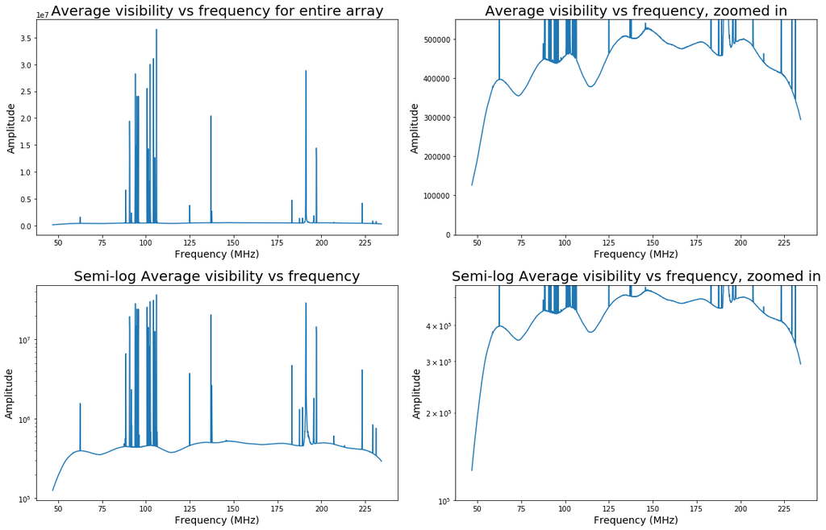

```python
fig, ax = plt.subplots(2,2, figsize=(16,10))
fig.tight_layout(w_pad = 5, h_pad = 5)

ax[0,0].plot(freqs, avgbackground)
ax[0,0].set_title('Average visibility vs frequency for entire array', fontsize=20)
ax[0,0].set_xlabel('Frequency (MHz)', fontsize=14)
ax[0,0].set_ylabel('Amplitude', fontsize=14)

ax[1,0].plot(freqs, avgbackground)
ax[1,0].set_title('Semi-log Average visibility vs frequency', fontsize=20)
ax[1,0].set_xlabel('Frequency (MHz)', fontsize=14)
ax[1,0].set_ylabel('Amplitude', fontsize=14)
ax[1,0].set_yscale('log')

ax[0,1].plot(freqs, avgbackground)
ax[0,1].set_title('Average visibility vs frequency, zoomed in', fontsize=20)
ax[0,1].set_xlabel('Frequency (MHz)', fontsize=14)
ax[0,1].set_ylabel('Amplitude', fontsize=14)
ax[0,1].set_ylim(0,.55e6)

ax[1,1].plot(freqs, avgbackground)
ax[1,1].set_title('Semi-log Average visibility vs frequency, zoomed in', fontsize=20)
ax[1,1].set_xlabel('Frequency (MHz)', fontsize=14)
ax[1,1].set_ylabel('Amplitude', fontsize=14)
ax[1,1].set_ylim(1e5,.55e6)
ax[1,1].set_yscale('log');
```

I want to get rid of most of those peaks, so I'm going to throw out any points greater than 0.55e6 for a more "smooth" background. Here's a semi-logged histogram of it:

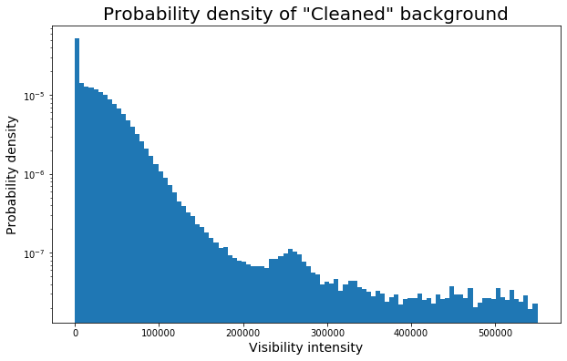

```python
back_flat = (np.array(background)).flatten()
back_clean = back_flat[back_flat<0.55e6]
plt.hist(back_clean, bins=100, density= True)
plt.title('Probability density of "Cleaned" background', fontsize=20)
plt.xlabel('Visibility intensity', fontsize=14)
plt.ylabel('Probability density', fontsize=14)
plt.yscale('log');
```

```python
sig, mean, scale = stats.lognorm.fit(back_clean)
```

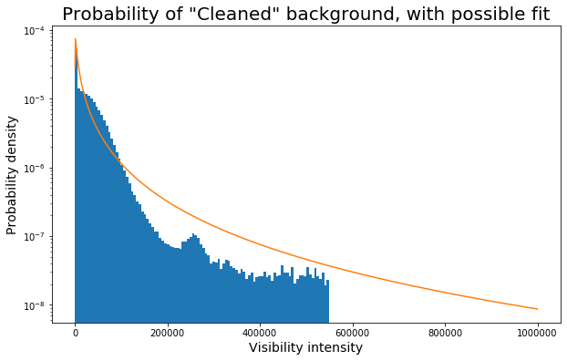

```python
plt.hist(back_clean,bins=100,density=True);
plt.plot(np.linspace(0,1e6,1000),stats.lognorm.pdf(np.linspace(0, 1e6,1000), s= sig, loc=mean, scale=scale))
plt.title('Probability of "Cleaned" background, with possible fit', fontsize=20)
plt.ylabel('Probability density', fontsize=14)
plt.xlabel('Visibility intensity', fontsize=14)
plt.yscale('log');
```

```python
model = stats.lognorm(sig, mean, scale)
five_sig = model.ppf(stats.norm.cdf(5))
print(f"My 5-sigma value of signal, using this model, is at {five_sig:.5e}.\nThis means I need a signal of intensity just over 61 million to claim detection.")
```

```
My 5-sigma value of signal, using this model, is at 6.11168e+07.
This means I need a signal of intensity just over 61 million to claim detection.
```

## Problem 2

Now inject a signal of known strength. You will want to make your signal moderately strong, say somewhere in the 8-30𝜎 range. Inject this signal into your background data many times.

### a) Histogram how bright the observed signal appears to be, and discuss its shape. Say in words what this histogram is telling you.

First, I'm injecting a 15-sigma signal over and over. Then, I'm plotting the historgram.

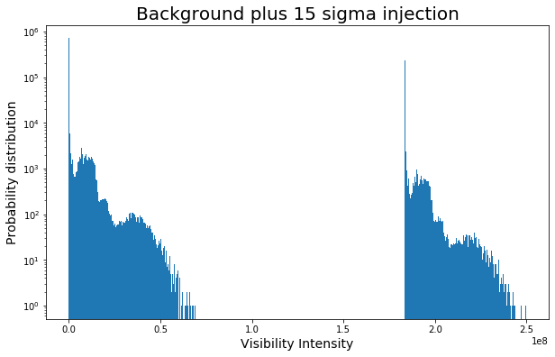

```python
inject = (np.random.rand(back_flat.size) < 0.25)* five_sig * 3 # five sigma strength times 3 lands me at 15 sigma, which is in range
total = back_flat + inject
plt.title('Background plus 15 sigma injection', fontsize=20)
plt.ylabel('Probability distribution', fontsize=14)
plt.xlabel('Visibility Intensity', fontsize=14)
plt.yscale('log')
plt.hist(total,bins=500);
```

The histogram shows the probability distribution background, and that of a signal at 15sigma (the one on the right). It looks like this because the signal we chose is so much stronger than the backround.

### b) Is your observed signal biased? (e.g. is the observed value equally likely to be stronger or weaker than the true injected signal?) Is it symmetric?

I think it is biased. The curve of the distribution itself is not symmetric, because it follows a lognormal distribution (which is not symmetric like a Gaussian). This means it's biased for values greater than zero (that's the shape of the lognorm- where the 'peak' is tells us about how likely values are to fall in that part of the distribution).

## Problem 3

Now make a suite of injected signals. You will want to have a range of injected signal strengths, starting at zero and extending well above 5𝜎 (30𝜎 or more). You will want to follow the work you did for Homework 5 very closely.

First, I am making my injected signal suite. I am using the same method as hw5, combined with my method in Problem 2 for how to generate the strengths. I want to take a subset of my orginal data to make this part manageable and avoid RAM death.

```python
subset= np.random.choice(back_flat,size=50_000) # avoiding RAM death
signal_strengths = np.linspace(0, 30*five_sig/5,500) # strenths in this range
injection = (np.random.rand(500,subset.size) < 0.25) # rate of injection
_, signal_strengths_grid = np.meshgrid(injection[0, :], signal_strengths)
signal = injection * signal_strengths_grid # pull it together

total2 = signal + subset # total thing to work with
```

a) Clearly state what you are simulating, and make a 2D histogram of injected signal vs. observed data

I am simulating "actual data". This is effectively the same thing as what we had taken from HERA initially, except this is somewhat controled versus the raw data, since we only took the background from what HERA had, and put in our own signals. Bellow is a 2D histogram:

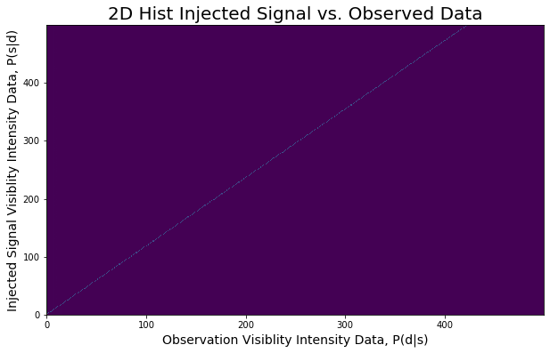

```python
fig,ax=plt.subplots()
Psd, temp, temp2=np.histogram2d(total2.flatten(), signal_strengths_grid.flatten(), bins=500, density=True)
plt.imshow(Psd.T,origin='bottom')
plt.gca().set_aspect('auto')
plt.title('2D Hist Injected Signal vs. Observed Data', fontsize=20)
plt.xlabel('Observation Visiblity Intensity Data, P(d|s)', fontsize = 14)
plt.ylabel('Injected Signal Visiblity Intensity Data, P(s|d)', fontsize = 14);
```

This looks kind of faint and weird- let's mess with the colormap for better visibility:

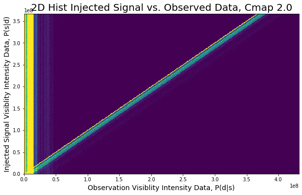

```python
fig,ax=plt.subplots()
Psd, temp, temp2=np.histogram2d(total2.flatten(), signal_strengths_grid.flatten(), bins=500)
plt.imshow(Psd.T,origin='bottom',extent=(0, total2.max(), signal_strengths.min(), signal_strengths.max()),vmin=1,vmax=100)
plt.gca().set_aspect('auto')
plt.title('2D Hist Injected Signal vs. Observed Data, Cmap 2.0', fontsize = 20)
plt.xlabel('Observation Visiblity Intensity Data, P(d|s)', fontsize = 14)
plt.ylabel('Injected Signal Visiblity Intensity Data, P(s|d)', fontsize = 14);
```

Much better! Now let's log the data, or the closest equivalent to it, since there's zeros in the data, and you can't log them. I'm shifting everything by one to avoid the grossness. Since it's logged and my values are large, the difference is very small if I do this.

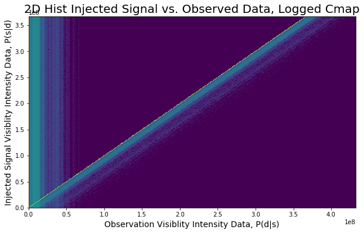

```python
fig,ax=plt.subplots()
Psd, temp, temp2=np.histogram2d(total2.flatten(), signal_strengths_grid.flatten(), bins=500)
plt.imshow(Psd.T+1,origin='bottom',extent=(0, total2.max(), signal_strengths.min(), signal_strengths.max()),norm=colors.LogNorm(vmin=1,vmax=Psd.max(),clip=True))
plt.gca().set_aspect('auto')
plt.title('2D Hist Injected Signal vs. Observed Data, Logged Cmap', fontsize = 20)
plt.xlabel('Observation Visiblity Intensity Data, P(d|s)', fontsize = 14)
plt.ylabel('Injected Signal Visiblity Intensity Data, P(s|d)', fontsize = 14);
```

This looks better. Here we can tell that the signals have a background distribution to them, and that it's not symmetrical (the brightest part fades into something to the "right" of the data).

### b) For the same injected signal power as in problem 2, show that you get the same answer.

Time to plot like we did for Problem 2, except the data will be from the `total2` variable.

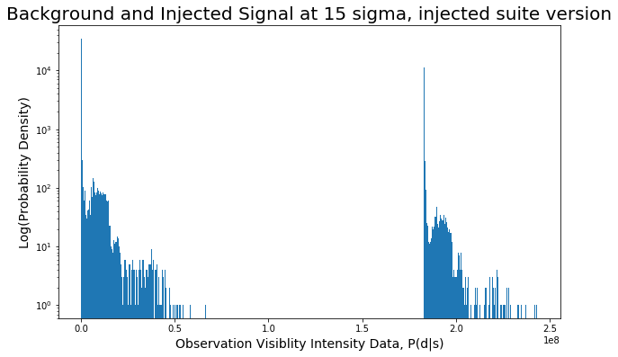

```python
index = abs(signal_strengths - five_sig*3).argmin()
vals = total2[index, :]
fig,ax=plt.subplots()
plt.yscale('log')
plt.xlabel('Observation Visiblity Intensity Data, P(d|s)', fontsize=14)
plt.ylabel('Log(Probability Density)', fontsize=14)
plt.title('Background and Injected Signal at 15 sigma, injected suite version', fontsize=20)
plt.hist(vals,bins=500);
```

This looks pretty similar to what I had before! This graph is a little more scarce because it's a subset, but the shape and overall pattern is the same.

### c) Now reverse the problem, select an observed data value (pick something quite a bit stronger than 5𝜎) and create a 1D histogram of the true signal probability given the observed data. Describe the meaning of this histogram.

[figure not shown]

```python
obs_val=signal_strengths[250] #picked value
fig,ax=plt.subplots()
x=np.linspace(signal_strengths.min(), signal_strengths.max(),500)
plt.yscale('log')
plt.xlabel('Injected Signal Visiblity Intensity Data, P(s|d)', fontsize=14)
plt.ylabel('Log(Probability Density)', fontsize=14)
plt.title(f'Injected Signal at Observed Strength {obs_val:0.1e}', fontsize=20)
plt.fill_between(x,Psd[250],step="pre");
#plt.hist(Psd[250],bins=500);
```

### d) For your observed signal, what is the 1𝜎 uncertainty on the true signal strength?

This is basically integration. We don't have the cdf of this distribution, so we do it "manually", then equate it to a normal distribution sigma, and get the uncertainty.

```python
point = Psd[250]
bins = np.linspace(signal_strengths.min(), signal_strengths.max(),50_000)

partial_sums = np.cumsum(point) / np.sum(point)
index = np.argmin(abs(partial_sums - stats.norm.cdf(-1)))
mariaiscool=bins[index - 1]
uncertainty = mariaiscool - bins[np.argmax(point)]

print(f"The 1 sigma uncertainty is {uncertainty}")
```

```
The 1 sigma uncertainty is -14668.336378614884
```

### e) Discuss the answer to part d in some depth. Is it symmetric? Is it biased? Does this make sense?

The uncertainty we get is in one direction only- this has to do with the fact that our lognormal distribution is not symmetric, and also biased to one side. This is why we have the one sigma - uncertainty, but not a sigma + uncertainty. This makes sense based on what I said before.